# Crisis Recovery in the CEE & SEE Creative & Cultural Sectors 2020

Daniel Antal, CFA

9/04/2020

-The Visegrad & SEE Regions, like the rest of the developed world, are heading towards the deepest economic recession since the World War 2. This is particularly hardly hitting the **creative and cultural industries**, including music, because these are **high-value added**, **labour-intensive** service industries where almost all the demand is wiped out.

-The economic rebuilding in region, like elsewhere in the EU, will include much **government intervention** and **public investments**, because private business investments will be very low due to the devastating economic recession.

-The economic conditions for the high-value added creative and cultural industries **before the crisis had been rather unfavourable** in Croatia, Hungary, Poland, Slovakia , because the economic policies of the previous governments favoured low-value added, export oriented industries - in the case of HU, SK, PL car manufacturing, and in the case of Croatia, tourism. This was also reflected in public investments.

-We are arguing for crisis and recovery policies that **prioritize re-employment, domestic value-added growth and domestic tax income**, and public investments into sectors that favour domestic value added and domestic tax base growth.

# LIVE MUSIC MARKET DEMAND

The regional demand for live music and generally cultural performances is relatively low compared to the income level of the country (See our [detailed report](http://ceereport2020.ceemid.eu/audience.html)). We believe that this is partly a supply and cultural education problem: the region is lacking a modern cultural performance infrastructure. ⯆ More on the live music market or ⯈ Next topics

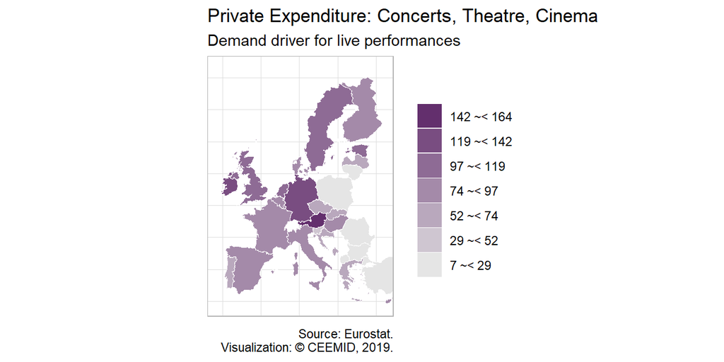

## Value of Concerts

The value of the concerts is mainly related to the purchasing power of the audience, which is at a medium level in a European comparison and relatively high, especially in Bratislava, compared to the Visegrad region. However, there are vast differences in Europe on how the concert tickets are taxed ⯆ More on the live music market, see also ⯈ Policy Proposals

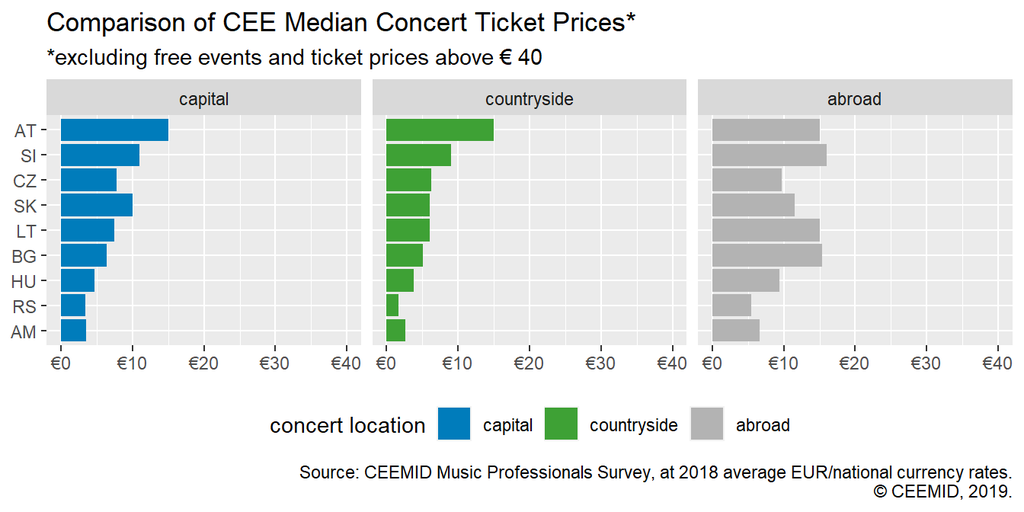

## Lack of Suitable Venues, Live Music Act

In Slovakia, the problem is mainly not related to the low price of the live music but to the limited audience size. This is not due to the relatively small population size of the country, but to the fact that individual concerts are small, and a modern cultural infrastructure is missing from the country. (See investment proposals.)

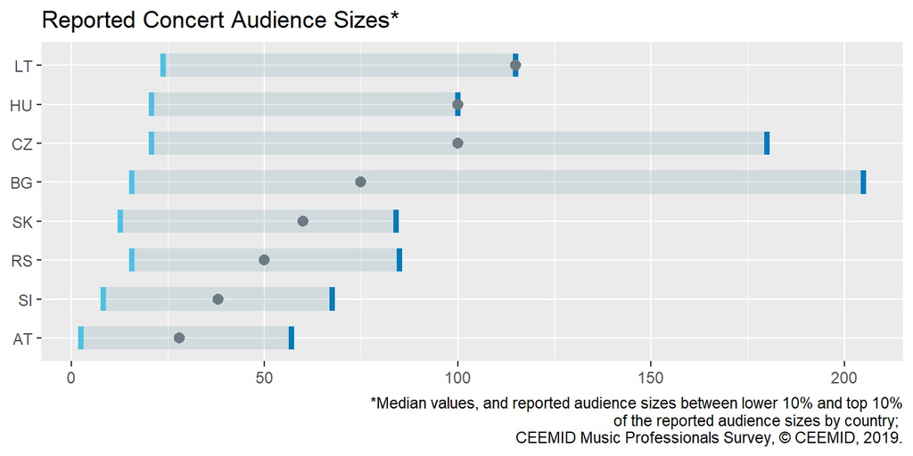

## Example: Financing of Music Events in Slovakia

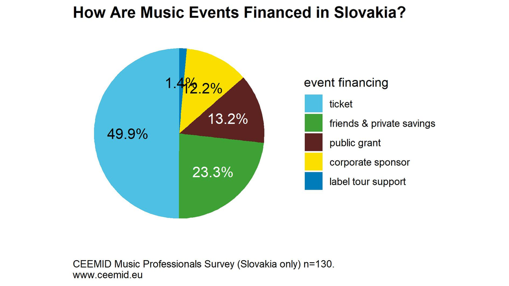

⯈ Next topics

# VALUE OF COPYRIGHTS & NEIGHBOURING RIGHTS

In the last ten years, live music was the breadwinner of musicians. After the collapse of record sales due to mass internet piracy and easy home copying, the recording industry could not provide significant income for musicians (see our [detailed report](http://ceereport2020.ceemid.eu/supply.html)). This is particularly true in countries where there was no adequate level of compensation for home copying. ⯆ More on the recorded market or ⯈ Next topics

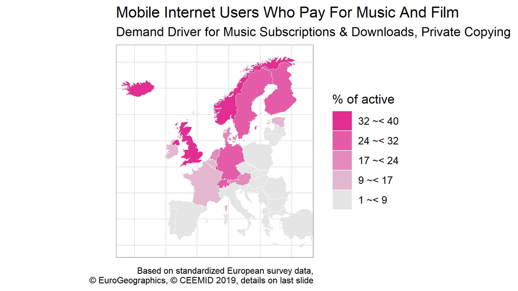

## The digital gap

- Even before the crisis, the CEE music markets were underdeveloped compared to the strength of market demand in the region. Central Europe is not poor, but lower quality of copyright protection, the lack of cooperationn among tiny national stakeholders makes business development challenging.
- Because many laws are going to change after the crisis, the industry should have an agreed strategy on how to close the gap in the next economic cycle, starting from the COVID-19 recovery steps.

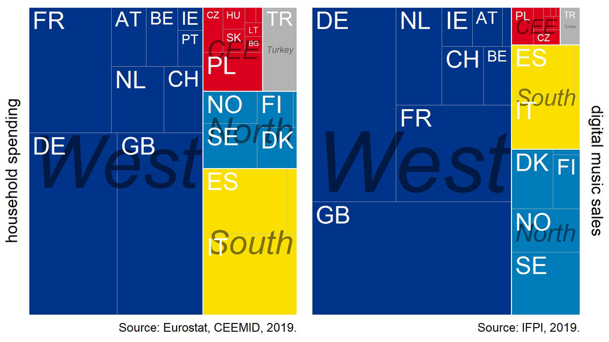

## Streaming Markets

[figure not shown]

# CREATIVE WORK

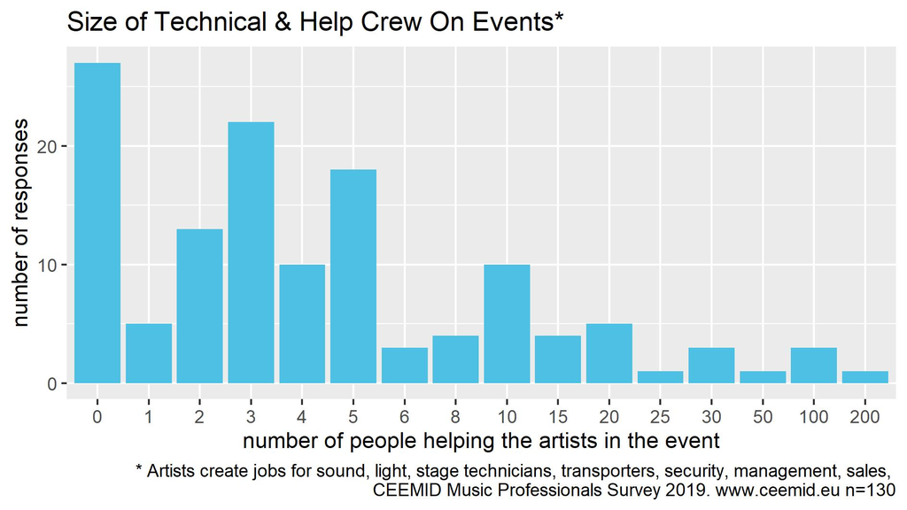

## Complex Carrier Routes

Many artists have important other artistic, technical, management or education roles in the music industry.

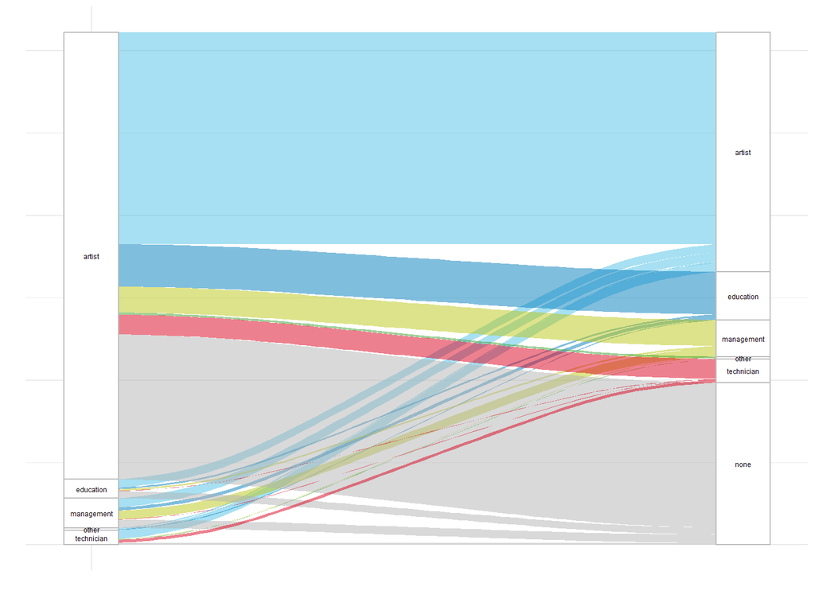

## Relative Income Levels

Slovak musicians, like creative workers in the film industry, television, theatres, have a low, risky, precarious income. The risk of not being able to pay monthly bills among creative workers is almost twice as that of the Slovak average person even before the crisis.

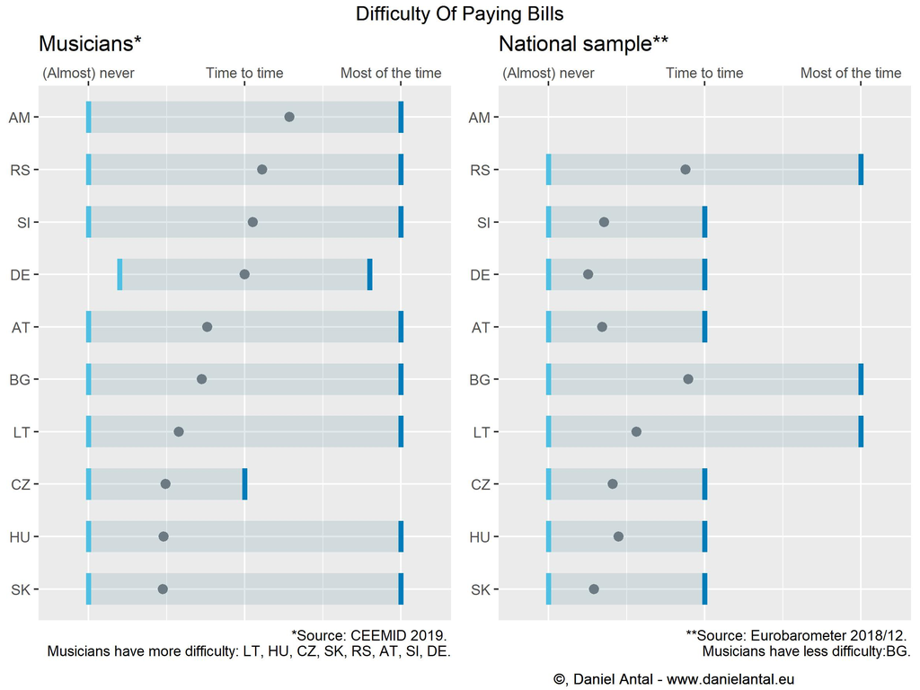

## Meaningful Work

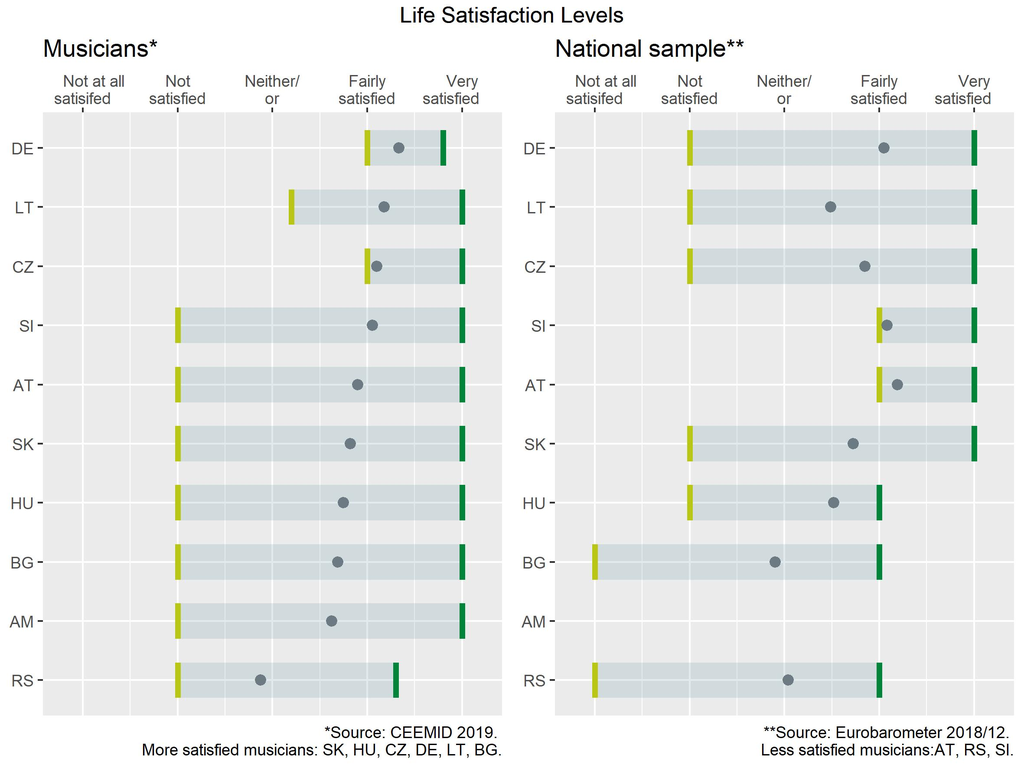

**Why prioritize creative industries**: - Creative workers do not have high revenue expectations, because they get satisfaction from their vocational & artistic calling.

- They create Slovak culture that promotes national cohesion and resilience.
- They pay higher taxes on turnover than almost all Slovak industries

# PUBLIC INVESTMENT PROPOSALS

- We are arguing for crisis and recovery policies that prioritize re-employment, domestic value-added growth and domestic tax income, and public investments into sectors that favour domestic value added and domestic tax base growth.
- Read ⯆ more on public investments or ⯈ Next topics

## Creative Infrastructure

- Several countries have created Live Music Acts, recognizing the high employment capacity of the music industry, and the special regulatory needs of the small venues. Nordic and Western countries did not only invest into the digitization of movie theatres, because music, theatre, dance and went through similar changes from the technology transition from analogue to digital.
- Building 21st century municipal cultural performing places, homes of culture, than can host theatre, film projection, dance and music on stages and spaces supported by digital technology can reduce operating costs of the industry and the cultural ministry with cost-sharing on a digital platform, create new jobs outside Bratislava and increase services to the Slovak public and the cultural tourism.

## Investments into AI

- The Austrian, Croatian, Hungarian, Slovak, Slovenian creative industries, similarly to EU and US creative enterprises, are mainly **microenterprises** (with less than 5 employees) that have no independent data-management and R&D functions.
- In the world, **the majority**, about 50-70% **of music*, and an increasing amount of **films, radio and televised content is sold by data-driven algorithms supported by AI**.
- Central European creatives are lacking the critical size to create large-enough data pools to train AI algorithms – Croatian, Hungarian, Slovak producers and the public broadcaster will loose out to the algorithms of YouTube, Netflix, Spotify, unless there are **national research programs** in this field.
- SOZA in Slovakia organized a national research & development consortium to help promoting Slovak music at home and globally. Unfortunately, the Arts Council only invested 5000 euros this critical national R&D project. We started organizing similar consortia in Czechia and Hungary, but our initial grant proposal to the International Visegrad Fund failed.

# POLICY PROPOSALS

- Our policy proposals are summarized in the [Central European Muisc Industry Report 2020](http://ceereport2020.ceemid.eu/) (see particularly [recommendations](http://ceereport2020.ceemid.eu/conclusions-policy-business-strategy-recommendations.html)), for [Croatia](https://www.zamp.hr/uploads/documents/Studija_privatno_kopiranje_u_Hrvatskoj_DA_CEEMID.pdf), [Slovak Music Industry Report 2019](https://danielantal.eu/publication/slovak_music_industry_2019), [Hungarian Music Industry Report](https://danielantal.eu/publication/hungary_music_industry_2014).
- In the crisis, we recommend governments and municipalities to finance early payment of collective royalties for composers, performers and producers, and to speed up pending court cases.
- We also strongly recommend the revision of collective tariffs, to build in automatic stabilizers for crises (automatic tariff changes in recession and in economic growth.)
- For artists, technicians and managers this is the best time to build up the missing, representative organizations of the sector that can meaningfully engage in the social dialogue about crisis recovery, tax, vocational educations and future economic policies. ⯆ More on the recorded market or ⯈ Next topics

# EVIDENCE-BASED CRISIS RECOVERY POLICIES

[figure not shown]

See our [detailed policy proposals](http://ceereport2020.ceemid.eu/conclusions-policy-business-strategy-recommendations.html) that are more timely than ever, given that many economic, labour and tax policies are under reconsideration. Europe enjoyed a decade of growth, but the CEE and SEE regions did not provide a good policy framework for creative industries. This time we can make it better. ⯆ More on the recorded market or ⯈Feedback & Questions

## Joint Market Research and R&D

- We would like to adopt models used in other CEE markets to critically review the value of royalties and whenever possible, to increase them in line with European benchmarks and jurisprudence.
- We would like to train algorithms and provide advanced analytics for SoundCzech, labels, publisher and concert promoters about contestable, profitable foreign markets.
- One aim of this research program is to develop strategic, effect and impact indicators to measure the development and make sure that the right direction is kept. This is also necessary for better grants.
- By combining data assets, research capacities we hope to provide stakeholders with better advocacy tools.

## Example: Slovak Proposals

- We have created an evidence-based music industry report that gives many tax, copyright regulation and economic policy proposals to increase the employment capacity, export capacity and tax base of the sector. CEEMID contains thousands of similar indicators for all creative industries, and in fact, all industries. We can assist economic policymakers to create better sectoral and economic policies.
- We are committed to future research. We have been planning empirical research (postponed because of the inability to visit randomly selected households during COVID-19) to argue for a better implementation of the DSM Directive for strengthening Slovak intellectual properties and copyrights. This postponement allows to join in this nationally representative, evidence-based research.
- We are investing into AI for music business. This is open for other creative industries, particularly film, radio, television, public broadcasters.

# FEEDBACK AND QUESTIONS

[figure not shown]

Contact: [danielantal.eu](https://danielantal.eu/) - [linkedin](https://www.linkedin.com/in/antaldaniel/) - [github](https://github.com/antaldaniel) - [dataverse](https://dataverse.harvard.edu/dataverse/harvard?q=%28dvName%3ADaniel+dvName%3AAntal%29+OR+%28authorName%3ADaniel+authorName%3AAntal%29)

Topics: [royalty valuation](https://danielantal.eu/usecase/royalty_setting/) - [private copying](https://danielantal.eu/post/dsm_pcr_19/) - [grant design](https://danielantal.eu/project/grants/) - [policy advocacy](https://danielantal.eu/publication/slovak_music_industry_2019/) - [ceemid observatory](https://danielantal.eu/project/ceemid/)

## Copyright Credits

In this presentation Open data was used with open source software components. Detailed references in long-form publications for all software code used.

- The European statistical maps: [© EuroGeographics](https://ec.europa.eu/eurostat/web/gisco/geodata/reference-data/administrative-units-statistical-units) for the administrative boundaries
- Visualization: [© Daniel Antal](https://danielantal.eu/), CEEMID, satellitereport.com 2019-2020.